# Analiza ofert dotyczących pokojów do wynajęcia z portalu gumtree.pl

Krzysztof Słomczyński

# Dlaczego taki temat?

Chciałem znaleźć taki temat, którego choć część wykonania będzie miała wymiar praktyczny. Na grupie [MI^2](http://mi2.mini.pw.edu.pl) składającej się głównie ze studentów i absolwentów MiNI PW i MIM UW funkcjonuje projekt CzasDojazdu. Ma on na celu dostarczenie aplikacji wyszukującej w Warszawie pokojów do wynajęcia pod kątem kryterium czasu dojazdu z mieszkania do pracy. Przeglądając go zauważyłem, że część danych pobieranych z portalu gumtree.pl jest błędnie zapisywanych (metraż), niektóre zaś są zupełnie pomijane (czy można palić lub trzymać zwierzęta, jaka jest preferowana płeć). Postanowiłem udoskonalić scraper funkcjonujący w tym projekcie, a na świeżo pobranych danych spróbowac zbudować model przewidujący ceny wynajmowanych pokoi.

## Udoskonalenie scrapera - zdobycie danych

Z pomocą pakietu `rvest` oraz wtyczki [SelectorGadget](http://selectorgadget.com) działającej w przeglądarce Chromium udało mi się wydobyć ze stron z ofertami interesujące mnie dane. Kod znaduje się w repozytorium projektu CzasDojazdu. Kolejne rejestry zapisywane są w bazie danych SQLite. Ponieważ wdrożenie kodu na produkcję ze względów organizacyjnych w takich projektach nieco trwa, zdecydowałem się na przerobienie go tak, aby dane zapisywane były do plików *.csv. Przypatrując się pobranym ofertom wiedziałem, że ich liczba przez czas realizacji projektu nie urośnie do dużych rozmiarów.

# Przygotowanie do projektu

W ramach przygotowania się do realizacji projektu ukończyłem dwa kursy.

- Machine Learning at Coursera by Andrew Ng
- Statistical Learning at Stanford ONLINE by Trevor Hastie and Robert Tibshirani

Oraz zapoznałem się z takimi narzędziami jak Crontab, Flume, Hadoop HDFS i Spark (pakiet `sparklyr`).

# Obróbka danych

```r
# Ładowanie bibliotek
library(dplyr)
library(readr)
```

Oferta dotycząca pokoju do wynajęcia na portalu gumtree.pl może zawierać następujące (powtarzalne) opcje wyboru:

1. Lokalizacja
- Miasto, Województwo
- Dokładny adres
2. Do wynajęcia przez
- “———”
- Właściciel
- Agencja
3. Współdzielenie
- Współdzielenie pokoju
- Współdzielenie mieszkania/domu
4. Dostępny
- Data w formacie %d/%m/%Y
5. Rodzaj nieruchomości
- “———”
- Mieszkanie
- Dom
- Inne
6. Wielkość (m2)
- Liczba typu Integer
7. Liczba pokoi
- “———”
- Kawalerka lub garsoneria
- 2 pokoje
- 3 pokoje
- 4 pokoje
- 5 pokoi
- 6 lub więcej pokoi
8. Palący
- “———”"
- Tak
- Nie
9. Przyjazne zwierzakom
- “———”"
- Tak
- Nie
10. Preferowana płeć
- “———”
- Mężczyzna
- Kobieta
- Bez preferencji
11. Cena
- Liczba typu Integer
- Proszę o kontakt
- Wymiana/zamiana

Zbierane są też dane dotyczące daty dodania oferty, link do ogłoszenia, opis i tutuł. Te jednak tym razem nie będą nas interesować ze względu na swój unikalny charakter.

Przyjrzyjmy się im nieco bliżej.

```r
# Ładowanie danych
dane1 <- read_csv("2016-10-26df.csv")
dane2 <- read_csv("2016-11-17df.csv")
dane <- rbind(dane1, dane2) %>% distinct()
rm(dane1, dane2)
```

```r
# Dane pod lupą - obróbka
dim(dane)
```

[output not shown]

```r
str(dane)
```

[output not shown]

Z dostępnych kolumn pozostawimy te które są unikalne. Dodatkowo skorzystamy jednak z opisów w celu policzenia ilości występujacych w nich słów.

```r
dane %>% names()
```

```
 [1] "data_dodania"         "lokalizacja"          "href"                 "opis"
 [5] "adres"                "cena"                 "tytuł"                "do_wynajęcia_przez"
 [9] "współdzielenie"       "wielkość_(m2)"        "liczba_pokoi"         "rodzaj_nieruchomości"
[13] "preferowana_płeć"     "palący"               "przyjazne_zwierzakom" "dostępny"
```

```r
names(dane) <-
  names(dane) %>% chartr("ąęółćśźż", "aeolcszz", .)
dane <-
  dane %>%
  rename(wielkosc  = `wielkosc_(m2)`) %>%
  select(-c(data_dodania, href, adres, tytul, dostepny)) %>%
  mutate(
    liczba_wyrazow = stri_count_words(opis)
  )
dane %>%
  select(-opis) %>%
  lapply(
    function(x) {
      x %>%
        table(useNA = "always") %>%
        sort(decreasing = TRUE) %>%
        head(20)
    }
  )
```

```
$lokalizacja
.
     Kraków, Małopolskie    Poznań, Wielkopolskie    Wrocław, Dolnośląskie            Łódź, Łódzkie
                    2894                     1302                      862                      438
       Mokotów, Warszawa    Śródmieście, Warszawa Praga Południe, Warszawa        Bielany, Warszawa
                     373                      372                      231                      205
      Targówek, Warszawa        Ursynów, Warszawa        Katowice, Śląskie           Wola, Warszawa
                     201                      198                      184                      156
        Bemowo, Warszawa         Ochota, Warszawa        Lublin, Lubelskie      Białołęka, Warszawa
                     142                      134                      106                      105
       Gdańsk, Pomorskie          Ursus, Warszawa   Praga Północ, Warszawa       Żoliborz, Warszawa
                      96                       68                       66                       62

$cena
.
Proszę o kontakt           600 zł           700 zł           800 zł           500 zł           550 zł
            1608              701              536              534              507              458
          650 zł           750 zł           900 zł         1 000 zł           450 zł           400 zł
             441              344              322              294              294              293
          850 zł           950 zł         1 200 zł           380 zł         1 100 zł           350 zł
             246              179              165              132              128              112
          300 zł           720 zł
              57               54

$do_wynajecia_przez
.
Właściciel       <NA>    Agencja
      7988        764        569

$wspoldzielenie
.
Współdzielenie mieszkania/domu          Współdzielenie pokoju                           <NA>
                          6813                           1423                           1085

$wielkosc
.
<NA>   12   20   10   15   50   14   60   25   16   18   80   55    9   11   70   13   48   40   65
2038  614  543  399  360  277  253  225  213  212  205  169  160  136  135  129  128  127  126  111

$liczba_pokoi
```

[output cut: 15 more lines]

```

$palacy
.
 Nie <NA>  Tak
4693 4079  549

$przyjazne_zwierzakom
.
<NA>  Nie  Tak
4429 3854 1038

$liczba_wyrazow
.
 45  19  31  44  29  59  36  47  91  22  43  25  35  53  64  26  42  23  33  37
104 101  95  92  89  88  86  86  84  83  83  82  82  82  82  81  80  79  79  79
```

Sprawdźmy rozkład ilości słów w opisach.

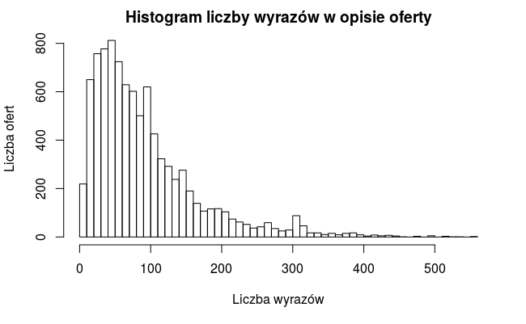

```r
hist(
  dane$liczba_wyrazow,
  50,
  main = "Histogram liczby wyrazów w opisie oferty",
  xlab = "Liczba wyrazów",
  ylab = "Liczba ofert"
)
```

Nie trudno było się domyślić, że najczęściej występujące opisy będą krótkie.

Usunę oferty zawierające w cenie informację `Proszę o kontakt` oraz te z `Wymiana/zamiana`. Tak samo postąpię z ofertami, które nie dostarczają informacji o powierzchni wynajmowanej przestrzeni. Dla takich kolumn jak `do_wynajęcia_przez`, `wspoldzielenie` i `liczba_pokoi` w miejsce brakujących wartości wstawię `"Nie podano"`, ponieważ ciężko w tych przpadkach doszukać się jakiegoś domyślnego ustawienia. Natomiast w przypadku `rodzaj_nieruchomosci` brak podanej wartości przypiszę do istniejącej opcji `Inne`. Kolejno `preferowana_plec` posiada wartość `Bez preferencji` i to ona zostanie przypisana w zamian za `NA`. Kierując się zasadą “Co nie jest prawem zabronione, jest dozwolone” założę, że nieokreślone wartości dla kolumn `palacy` oraz `przyjazne_zwierzakom` przyjmują wartości `Tak`. Na koniec `cena` zostaje pozbawiona informacji o walucie i zamieniona na liczbę typu Integer, a klasy odpowiednich zmiennych zostają zamienione na faktory.

```r
dane <-
  dane %>%
  filter(
    grepl(("Warszawa|Kraków"), lokalizacja),
    !(cena %in% c("Proszę o kontakt", "Wymiana/zamiana")),
    !is.na(wielkosc)
  ) %>%
  mutate(
    do_wynajecia_przez = do_wynajecia_przez %>%
      plyr::mapvalues(NA, "Nie podano") %>%
      as.factor(),
    wspoldzielenie = wspoldzielenie %>%
      plyr::mapvalues(NA, "Nie podano") %>%
      as.factor(),
    liczba_pokoi = liczba_pokoi %>%
      plyr::mapvalues(NA, "Nie podano") %>%
      as.factor(),
    rodzaj_nieruchomosci = rodzaj_nieruchomosci %>%
      plyr::mapvalues(NA, "Inne") %>%
      as.factor(),
    preferowana_plec = preferowana_plec %>%
      plyr::mapvalues(NA, "Bez preferencji") %>%
      as.factor(),
    palacy = palacy %>%
      plyr::mapvalues(NA, "Tak") %>%
      as.factor(),
    przyjazne_zwierzakom = przyjazne_zwierzakom %>%
      plyr::mapvalues(NA, "Tak") %>%
      as.factor(),
    cena = stri_extract_all_charclass(
      cena, "[[:digit:]]"
    ) %>%
      stri_join_list() %>%
      as.integer()
  )
dane %>% summary()
```

```
 lokalizacja            opis                cena         do_wynajecia_przez                        wspoldzielenie
 Length:3564        Length:3564        Min.   :   1.0   Agencja   : 188     Nie podano                    : 207
 Class :character   Class :character   1st Qu.: 550.0   Nie podano: 186     Współdzielenie mieszkania/domu:2794
 Mode  :character   Mode  :character   Median : 700.0   Właściciel:3190     Współdzielenie pokoju         : 563
                                       Mean   : 739.4
                                       3rd Qu.: 900.0
                                       Max.   :8000.0

    wielkosc                         liczba_pokoi  rodzaj_nieruchomosci        preferowana_plec palacy
 Min.   :   1.00   2 pokoje                : 929   Dom       : 482      Bez preferencji:2319    Nie:1907
 1st Qu.:  15.00   3 pokoje                :1303   Inne      : 216      Kobieta        : 905    Tak:1657
 Median :  37.50   4 pokoje                : 384   Mieszkanie:2866      Mężczyzna      : 340
 Mean   :  44.52   5 pokoi                 : 141
 3rd Qu.:  60.00   6 lub więcej pokoi      : 198
 Max.   :1200.00   Kawalerka lub garsoniera: 123
                   Nie podano              : 486
 przyjazne_zwierzakom liczba_wyrazow
 Nie:1709             Min.   :  2.0
 Tak:1855             1st Qu.: 45.0
                      Median : 83.0
                      Mean   :106.1
                      3rd Qu.:140.0
                      Max.   :558.0
```

Stosując zasadę ograniczonego zaufania (wiele osób mogło pomylić się podczas wystawiania oferty) przyjrzyjmy się bliżej wartościom przyjmowanym przez cenę oraz wielkość. Po nich spodziewalibyśmy się dość silnej korelacji.

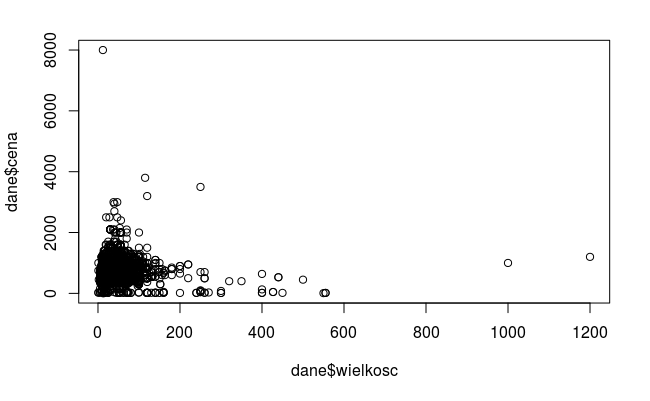

```r
plot(dane$wielkosc, dane$cena)
```

Wykres zdecydowanie psują pozycje z ceną powyżej 5000 złotych oraz powierzchnią powyżej 600 metrów kwadratowych. Przyjrzyjmy sie bliżej tym ofertom.

```r
dane %>%
  filter(cena == 8000) %>%
  .$opis
```

```
[1] "wynajmę duży pokój z balkonem. Zamykany, umeblowany. W mieszkaniu wszystkie potrzebne sprzęty: lodówka, pralka, kuchenka. Pozostałe pokoje zajęte przez osoby pracujące i studiujące także potrzeba osoby spokojnej i sympatycznej. koszty: osoba pojedyncza 800 + opłaty licznikowe para 1000 + opłaty…
```

Z treści oferty wynika, że cena za jeden pokój dla osoby to 800 pln. Autor oferty dopisał jeden rząd wielkości do ceny. Przypatrzmy się tym od 3000 w górę.

```r
dane %>%
  filter(between(cena, 3000, 4000)) %>%
  .$opis
```

```
[1] "DWUPOZIOMOWE MIESZKANIE ODDALONE 3 KM OD CENTRUM KRAKOWA. W POBLIŻU ZNAJDUJĄ SIĘ MIN. PARK AWF, TAURON ARENA KRAKÓW, M1, PLAZA, POLITECHNIKA KRAKOWSKA.DOBRY DOJAZD ZARÓWNO DO CENTRUM KRAKOWA JAK I NOWEJ HUTY."
[2] "Wynajme 2 pokojowe mieszanie na krotki okres (1-3miesiace)Mieszkanie (38m2) znajduje w centrum (Metro Rondo ONZ/Ul.Krochmalna 2). Mieszkanie jest kompletnie wyposażone (pralka, sprzęt kuchenny, lodowka, etc.) \r\nLokalizacja : W centrum, w pobliżu przystanku autobusowy/tramwajowa i metra.\r\nWy…
[3] "Wynajme 2 pokojowe mieszanie na krotki okres (1-3miesiace)Mieszkanie (38m2) znajduje w centrum (Metro Rondo ONZ/Ul.Krochmalna 2). Mieszkanie jest kompletnie wyposażone (pralka, sprzęt kuchenny, lodowka, etc.) \r\nLokalizacja : W centrum, w pobliżu przystanku autobusowy/tramwajowa i metra.\r\nWy…
[4] "Wynajmę dom nieumeblowany przy ul.Kasztanowej na Woli Justowskiej dla grupy studentów lub firmie dla pracowników do czerwca 2017 roku.Blisko do przystanku komunikacji autobusowej - 100 metrów, sklep 150 metrów.Kuchnia jest umeblowana, łazienki też umeblowane-pralka automatyczna też jest.Dom pos…
[5] "Wynajmę pokoje dla osób starszych z opieką medyczną . Cena do uzgodnienia. KONTAKT - LIGKAC@WP.PL"
```

Powyższe przypadki opisują całe mieszkania (lub domy) do wynajęcia. Cena podana jest za mieszkanie/dom (sumę pokojów). W serwisie gumtree.pl istnieje osobny dział do wystawiania takich ofert o nazwie `mieszkania i domy do wynajęcia`. Sprawdźmy co dzieje się przy cenach między 2000 a 3000.

```r
dane %>%
  filter(between(cena, 2000, 3000)) %>%
  .$opis
```

```
 [1] "Mam do wynajecia 2 przechodni pokoje do wynajecia w tym samym mieszkaniu w centrum (Metro Ratusz arsenal.Ul Anielewicza 4)  Pokój jest12m który znajduje się w mieszkaniu 3 pokojowym w bloku dzielnica centrum. Mieszkanie jest kompletnie wyposażone (pralka, sprzęt kuchenny, telewizja kablowa, et…
 [2] "Mam do wynajecia duzy pokoj do wynajecia w centrum (Metro Ratusz Arsenal/Ul.Anielewicza 4) Pokój jest 26m który znajduje się w mieszkaniu 2 pokojowym w bloku dzielnica centrum. Mieszkanie jest kompletnie wyposażone (pralka, sprzęt kuchenny, telewizja kablowa, etc.) \r\nLokalizacja : W centrum,…
 [3] "Mieszkanie na Żoliborzu, ul. Dymińska obok Cytadeli.2 pokoje, 1 piętro, blok z cegły.Mieszkanie czyste, ciche, słoneczne, umeblowane, kuchnia widna, osobna, Łazienka z kabiną prysznicową.BARDZO DOBRA LOKALIZACJA! Zielono, dużo miejsc spacerowych.Wymagana jednomiesięczna kaucja.Koszt najmu wyno…
 [4] "Duzy Pokoj dla 1-2osob Od zarazPiekny pokoj do wynajecia W centrum (Metro Ratusz Arsenal/ul.Adersa24) Wynajme pokój 26m2 który znajduje się w 2 pokojowym mieszkaniu. Mieszkanie jest dobrym standardzie kompletnie wyposażone (pralka, zmywarka, sprzęt kuchenny, telewizja kablowa, etc.) Nie toleru…
 [5] "Duzy Pokoj dla 1-2osob Od zarazPiekny pokoj do wynajecia W centrum (Metro Ratusz Arsenal/ul.Adersa24) Wynajme pokój 26m2 który znajduje się w 2 pokojowym mieszkaniu. Mieszkanie jest dobrym standardzie kompletnie wyposażone (pralka, zmywarka, sprzęt kuchenny, telewizja kablowa, etc.) Nie toleru…
 [6] "Dwa nieprzechodnie pokoje z dwoma podwójnymi łóżkami i widokiem na skwer. Oddzielna kuchnia i oddzielna łazienka. Mieszkanie usytułowane na Kazimierzu 10 minut od i Wisły.W pobliżu puby, restauracje i sklep całodobowy.Przystanek tramwajowy i autobusowy za rogiem.Mieszkanie jest w pełni wyposaż…
 [7] "Piekny Duzy Pokoj dla 1-2osob Od zarazPiekny pokoj do wynajecia W centrum (Metro Ratusz Arsenal/ul.Adersa24) Wynajme pokój 26m2 który znajduje się w 2 pokojowym mieszkaniu. Mieszkanie jest dobrym standardzie kompletnie wyposażone (pralka, zmywarka, sprzęt kuchenny, telewizja kablowa, etc.) Nie…
 [8] "Do wynajęcia duży, komfortowy pokój dla 2-3 osób w 3-pokojowym mieszkaniu w kamienicy ( I piętro ). Okolice mostu Dębnickiego.Wspólna łazienka, kuchnia ( z balkonem ) i przedpokój ( w pozostałych pokojach mieszkają 3 osoby).Pokój po remoncie. Nowe wyposażenie (meble): łóżka, biurka, fotele (na…
 [9] "Mam do wynajecia duzy pokoj 26sq.m do wynajecia w centrum (Metro Ratusz Arsenal/Ul.Anielewicza 4) Pokój jest 26m który znajduje się w mieszkaniu 2 pokojowym w bloku dzielnica centrum. Mieszkanie jest kompletnie wyposażone (pralka, sprzęt kuchenny, telewizja kablowa, etc.) \r\nLokalizacja : W c…
[10] "Do wynajęcia dwa mieszkania/kawalerki, znajdujące się obok siebie, na krótko lub dłużej, przytulne i funkcjonalne. W\r\nsamym centrum starego miasta (ul. Zyblikiewicza), w trzypiętrowej zadbanej\r\nkamienicy.Każde posada przestronny pokój dzienny\r\npołączony z sypialnią, aneks kuchenny i łazi…
[11] "Wynajme duzy pokoj na krotki okres (1-3miesiace)Duzy samodzielny pokoj do wynajecia W centrum (Metro Ratusz arsenal/Ul.anielewicza 4) pokój jest 24m który znajduje się w mieszkaniu 2 pokojowym w bloku dzielnica centrum. Mieszkanie jest kompletnie wyposażone (pralka, sprzęt kuchenny, telewizja …
[12] "Wynajme 2 pokojowe mieszanie na krotki okres (1-3miesiace)Mieszkanie (38m2) znajduje w centrum (Metro Rondo ONZ/Ul.Krochmalna 2). Mieszkanie jest kompletnie wyposażone (pralka, sprzęt kuchenny, lodowka, etc.) \r\nLokalizacja : W centrum, w pobliżu przystanku autobusowy/tramwajowa i metra.\r\nW…
[13] "Do wynajęcia od zaraz nowe mieszkanie urządzone w wysokim standardzie na strzeżonym zamkniętym osiedlu fi w krakowie przy ul. Szafrana 5Mieszkanie zlokalizowane jest na 2 piętrze - okna od strony zachodniej - dobrze doświetlone, jasne, przestronnePodłoga - deska lita olejowanaKuchnia - otwarta…
[14] "PolskiWyjątkowy apartament dostępny na długi lub krótki okres od zaraz.2 pokoje niezależne: 18m2 i 12 m2. Mniejszy pokój z balkonem. Z większego pokoju piękny widok na zieleń. Czynsz: 1900 zł + rachunki (internet jest w cenie) lub 2600 zł all inclusiveBudynek położony jest 5 min pieszo do Gale…
[15] "Mam do wynajecia duzy pokoj 26sq.m do wynajecia w centrum (Metro Ratusz Arsenal/Ul.Anielewicza 4) Pokój jest 26m który znajduje się w mieszkaniu 2 pokojowym w bloku dzielnica centrum. Mieszkanie jest kompletnie wyposażone (pralka, sprzęt kuchenny, telewizja kablowa, etc.) \r\nLokalizacja : W c…
```

[output cut: 22 more lines]

Tym razem cena części ofert faktycznie dotyczy jednego pokoju do wynajęcia w dwópokojowym mieszkaniu w pobliżu stacji Metro Ratusz Arsenał. Niestety podany metraż dotyczy całego mieszkania.

Przyjrzyjmy się teraz skrajnym wielkościom.

```r
dane %>%
  filter(wielkosc >= 1000) %>%
  .$opis
```

```
[1] "2 Piekni przechodni pokoje do wynajecia W centrum (Metro Ratusz arsenal/Ul.andersa 24) Kazdy pokój ma 14m który znajduje się w mieszkaniu 3 pokojowym w bloku dzielnica centrum. Mieszkanie jest kompletnie wyposażone (pralka, sprzęt kuchenny, telewizja kablowa, etc.) \r\nLokalizacja : W centrum, …
[2] "Wynajme pokoje na krotki okres (1-3miesiace)Piekni pokoje do wynajecia W centrum (Metro Ratusz arsenal/Ul.andersa 24) pokóje sa 14m który znajduje się w mieszkaniu 3 pokojowym w bloku dzielnica centrum. Mieszkanie jest kompletnie wyposażone (pralka, sprzęt kuchenny, zmywarka, telewizja kablowa,…
```

Ciekawe, że dwie najbardziej skrajne oferty pod względem wielkości to kopie najbardziej skranych ofert pod względem ceny. Oczywiście zawierają one błąd i zostaną usunięte. Sprawdźmy co z nieco mniejszymi.

```r
dane %>%
  filter(between(wielkosc, 200, 600)) %>%
  .$opis
```

```
 [1] "Hostel z przeznaczeniem dla pracowników i grup zorganizowanych. Bardzo dobre warunki w doskonałej lokalizacji za przyzwoitą cenę.Pokoje 4-, 6- i 8-osobowe.  Także jeden pokój 2-osobowy W każdym pokoju internet WiFi oraz telewizorŁazienki z nowymi prysznicami. Kuchnia w pełni wyposażona (lodówk…
 [2] "Warsawa Targówek ul. Oszmiańska 7 okilce Ronda ŻabaOferujemy pokoje 2, 3, 4 osobowe w hotelu pracowniczym .Pokoje umeblowane , TV , lodówka , internet , czyste i ciepłe . Do dyspozycji kuchnia wyposażona w naczynia i niezbędny sprzęt AGD do gotowania. Dwa węzły sanitarne z WC , umywalkami , na…
 [3] "Noclegi. Pokoje dla Pracowników. Kwatery dla firm.Pokoje 2, 3, 4, 5, 6, 7 osobowe.Obiekt sprzątany codziennie. WiFi, parking za darmo.Ceny  pojedyncza doba - 35 zl.                tydzień - 150 zl.               miesiąc - 550 zl. od osoby.Zapraszamy: 575 537 419"
 [4] "Praca szuka człowieka. 1300zl + pokój na osobnym piętrze. Pierwszy miesiąc próbny 1000zł. Pokój znajduje się na piętrze, gdzie kiedyś był garaż i piwnice, obecnie znajduje się pokój z przeszkloną całą ścianą, wyjściem na małe patio, z którego jest wyjscie na małą uliczkę (osloniete od ulicy), …
 [5] "noclegi 16, 5 Zl\r\nW\r\nnowym, estetycznym, nowoczesnym hostelu oferują łóżka.Pokoje\r\ndla 4 i 6 osób.Zapraszamy\r\ngości miasta, podróżujących w interesach, jak i studentów.\r\nOddzielne pokoje męskie i żeńskie.Miesiąc\r\n= 495 złtydzień\r\n= 149 zł.dzień\r\n= 24, 9 zł.Oferujemy\r\nrównież …
 [6] "Noclegi:miejscowość Łazy, Gmina Jerzmanowice okolice Ojcowa-                                              Do Dyspozycji gości:- 1 pok 2 os. łazienką- 2 pok. 2 os z możliwością dostawki- 2 pok 3 os.z możliwością dostawki+ 2 duże łazienki i 2 osobne WC + aneks kuchenny z naczyniami, kuchenka mik…
 [7] "ZAMYKANY NA KLUCZ, , W OSOBNEJ CZĘŚCI DOMU, UMEBLOWANY W PEŁNI, POZOSTAŁE POKOJE WEJŚCIE Z INNEJ STRONY OD KORYTARZA, OBOK KUCHNIA I ŁAZIENKA, DOJAZD NA pk, DWORZEC LINIĄ 105, AGH 139, UEK 184 SZYBKO W 10 - 15 MINUT, DOBRU W 10 MIN. DOJAZD DO GALERII KRAKOWSKIEJ, 3 PRZYSTANKI, MULTIKUNO, REAL,…
 [8] "W przypadku pytań i rezerwacji prosimy o kontakt telefoniczny: 530 033 423 .OFERTADo dyspozycji gości mamy pokoje 1/2/3/4 osobowe z TV.W hostelu jest darmowe wifi.LOKALIZACJAMieścimy się w budynku zlokalizowanym w willowej części Warszawy. Ulica przy której się znajdujemy jest bardzo cicha, a …
 [9] "Dom jest 13 kilometrów na południowy zachód od Krakowa.Okolice Włosania Gmina Mogilany.Powiat Kraków.Cena za dobę od 8 do 20 złotych za Osobę.Koszt zależy od ilości Osób, długości najmu oraz liczby zajętych pokoi.Możliwość rozliczenia części należności za najem w pracach remontowo-wykończeniow…
[10] "Witam, Zapraszam do wynajęcia jednego z naszych pokoi. Do wynajęcia mamy 1 pokój jednoosobowy. Dostępny od zaraz. Mieszkanie w bardzo atrakcyjnej lokalizacji blisko metra Kabaty. Mieszkanie składa się z 14 nieprzechodnich pokoi, ogólnodostępnej kuchni, 3 niezależnych łazienek. Wysoki standard.…
[11] "Wynajmę pokoje w unikatowym modernistycznym domu wielorodzinnym z 1937 roku na Starych Dębnikach przy ul. Czarodziejskiej.Czynsz za łóżko w pokoju 2/3 osobowym to 400zł + 50 zł ryczałt za media. Pokoje są wyposażone, ogrzewane i zamykane na klucz. Istnieje również możliwość wynajęcia samodziel…
[12] "pokoj w domu jednorodzinnym 15m umeblowany mozliwosc parkowania auta pod domem w pelni umeblowany"
[13] "Zapraszamy do naszych kwater pracowniczych , polozonej blisko skrzyżowania MŁODZIEŃCZA     -RADZYMIŃSKA .\r\nOferujemy pokoje trzy oraz pięcio osobowe.\r\nPokoje są wyposarzone w :\r\n- Łóżka \r\n- Pościel\r\n- Telewizory\r\n- Szafy\r\n- Stoliki\r\nDo wspólnego wykorzystania:\r\n- Kuchnia (lod…
[14] "KAWALERSKIE, WIECZÓR PANIEŃSKI, W LESIE NAD RZEKĄ. IMPREZY DLA GRUPY PRZYJACIÓŁ- POKOJE 2, 3, 4 OSOBOWE- KUCHNIA Z PEŁNYM WYPOSAŻENIEM AGD-SALA Z KOMINKIEM NA DRZEWO- MIEJSCE NA OGNISKO I GRILA-TARASY BIESIADNE-TV SATELITARNA- WI-FI-WYŻYWIENIE, STOŁY BIESIADNE, WYROBY WŁASNE.MOŻLIWY SPŁYW KAJA…
[15] "Zapraszamy do naszych kwater pracowniczych , polozonej blisko przystanku JORSKIEGO (RADZYMIŃSKA)\r\nOddalonej o 10 min od Dworca Wileńskiego.\r\nOferujemy pokoje trzy oraz pięcio osobowe.\r\nPokoje są wyposarzone w :\r\n- Łóżka \r\n- Pościel\r\n- Telewizory\r\n- Szafy\r\n- Stoliki\r\nDo wspóln…
```

[output cut: 25 more lines]

Oferty te dotyczą hoteli pracowniczych lub całych domostw. Tym razem to cena podana jest za pokój, a wielkość opisuje metraż całego mieszaknia/domu. Niestety nie ma żadnej konsekwencji w podawaniu przez oferantów ceny i wielkości powierzchni wynajmu. Raz podany jest metraż całego mieszkania z ceną za pokój i liczbą pokojów. Innym razem podany jest metraż pokoju z ceną za wszystkie pokoje i podaną liczbą pokojów. Żeby ustandaryzować te oferty trzebaby przeprowadzić wyrafinowaną analizę treści opisu, lub wprowadzić poprawki ręcznie, czytając każdą ofertę po kolei. Na potrzeby projektu ograniczę się do usunięcia tak skrajnych przypadków, aż nie uzyskam w miarę rozsądnej korelacji między tymi dwoma wartościami.

Przyjrzyjmy sie jeszcze ofertom posiadającym wyjątkowo niską cenę (poniżej 100 PLN) i bardzo mały metraż (10 m^2).

```r
dane %>%
  filter(
    cena <= 100,
    wielkosc <= 10
  ) %>%
  .$opis
```

```
[1] "DO DYSPOZYCJI GOŚCI ODDAJEMY 36 miejsc noclegowych na dwóch kondygnacjachPosiadamy 6 pokoi 6-osobowych. Oferta skierowana do grup.Pokoje są ogrzewane c.o. i wyposażone w:-łóżka (piętrowe i pojedyncze)-szafę ubraniową-szafki nocne-stół-krzesła-lampkę nocną-gniazdko internetowePonadto na każdym p…
[2] "HOSTEL tanie noclegi pokoje kwatery do wynajęcia WARSZAWA Wilanów Mokotów\r\n\r\n\r\nPokoje Gościnne w Klimatycznej Willi z lat 70tych na Sadybie-Mokotów\r\nZdrojowa 28 Hostel.\r\n\r\n\r\nwww.Zdrojowa28Hostel.pl\r\n\r\n\r\nInformacje poprzez kontakt telefoniczny 9:00-20:00\r\nlub mailowy \r\nZa…
[3] "Do okoła pełno kawiarni i restauracji. Po przejściu mostu jesteśmy w Centrum. Niezwykle cicha okolica z dala od zgiełku miasta."
[4] "Oferujemy komfortowe pokoje w przystępnej cenie na Bemowie w Warszawie.\r\nPokoje 2, 3-4 osobowe z tv, internetem i czystą pościelą. Kuchnia w pełni wyposażona, 3 łazienki z prysznicem. Bezpieczne miejsca parkingowe.\r\nDoskonała lokalizacja- Warszawa Bemowo blisko Ul.Powstańców Śląskich, Górcz…
[5] "Jesteś przejazdem w Katowicach i szukasz noclegu blisko centrum? Oferujemy wygodne pokoje w przystępnej cenie. Mieścimy się tylko kilkaset metrów od Spodka w spokojnej dzielnicy - Koszutka. U nas w cenie pokoju pooglądasz kablówkę i skorzystasz z bezpłatnego wifi. Mamy 7 pokoi 2-3 i 4 osobowych…
[6] "Oferujemy komfortowe pokoje w przystępnej cenie na Bemowie w Warszawie.\r\nPokoje 2, 3-4 osobowe z tv, internetem i czystą pościelą. Kuchnia w pełni wyposażona, 3 łazienki z prysznicem. Bezpieczne miejsca parkingowe.\r\nDoskonała lokalizacja- Warszawa Bemowo blisko Ul.Powstańców Śląskich, Górcz…
[7] "DO DYSPOZYCJI GOŚCI ODDAJEMY 36 miejsc noclegowych na dwóch kondygnacjachPosiadamy 6 pokoi 6-osobowych. Oferta skierowana do grup.Pokoje są ogrzewane c.o. i wyposażone w:-łóżka (piętrowe i pojedyncze)-szafę ubraniową-szafki nocne-stół-krzesła-lampkę nocną-gniazdko internetowePonadto na każdym p…
```

W tych ofertach zdecydowanie nieprawidłowo podano wielkość. 6 osobowy pokój raczej nie ma 5 m^2, zaś 3-4 osobowy nie ma 1 m^2.

Decyduję się więc na ograniczenie zestawu danych ze względu na cenę i wielkość przyjmując nieco węższe - eliminujące wadliwe oferty - widełki.

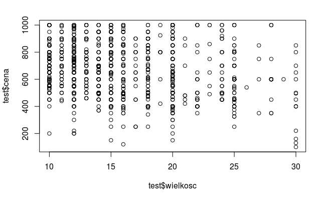